# Lecture 3-3: The Spatial Dimension - Economic Complexity

Daniel S. Hain (dsh@business.aau.dk)

19 April, 2021

```r
### Load packages
# Note: Maybe pacman needs to be installed
pacman::p_load(tidyverse # Collection of all the good stuff like dplyr, ggplot2 ect.
               , magrittr # For extra-piping operators (eg. %<>%)
               , tidygraph # For tidy-style graph manipulation
               , ggraph # For ggplot2 style graph plotting
               , ggmap # Geoplotting / coding
               )
```

# A closer look at the Chinese patenting activity

## Loading and understanding the data structure

So, let’s start the fun. I for you extracted Chinese patents from our EPO [PATSTAT](https://www.epo.org/searching-for-patents/business/patstat.html) databases filed at either the EPO or the USTPO. I further provide you adittional data. Lets take a look:

```r
patents <- readRDS(url("https://github.com/daniel-hain/SDC_IM/raw/master/data/CN_patent.rds"))
inventors <- readRDS(url("https://github.com/daniel-hain/SDC_IM/raw/master/data/CN_inventor.rds")) %>% filter(str_detect(city, "china")) %>% mutate(city = city %>% str_remove("\\,.*"))
el_pat_inv <- readRDS(url("https://github.com/daniel-hain/SDC_IM/raw/master/data/CN_el_inventor_patent.rds"))
el_pat_tech <- readRDS(url("https://github.com/daniel-hain/SDC_IM/raw/master/data/CN_el_patent_field.rds"))
```

```r
field_names <- read_csv(url("https://github.com/daniel-hain/SDC_IM/raw/master/data/ipc_technology.csv")) %>%
  select(field_nr, sector, field_name) %>%
  distinct(field_nr, .keep_all = TRUE) %>%
  mutate(field_nr = field_nr) %>%
  arrange(field_nr)
```

```r
cities_geo <- inventors %>%
  distinct(city, .keep_all = TRUE) %>%
  select(city, lon, lat)
```

```r
reg_pat <- el_pat_inv %>%
  arrange(appln_id, invt_seq_nr) %>%
  distinct(appln_id, .keep_all = TRUE) %>%
  left_join(inventors %>% select(person_id, city), by = "person_id") %>%
  left_join(patents %>% select(appln_id, appln_filing_year, nb_citing_docdb_fam), by = "appln_id") %>%
  select(-invt_seq_nr, person_id)
```

# Economic complexity of Chinese patenting activity

Let’s not take a look at the complexity of Chinese patenting activity.

We will here use some neath functions from the`R` package `EconGeo`. Its only on github, so we have to install it from there.

```r
#remotes::install_github("PABalland/EconGeo", force = T)
library(EconGeo)
```

## Data munging

First, here we will need to create some big matrices, therefore I will here already define a little helper function which takes an edgelist as input and produces really efficient a sparse `M[i,j]` 2-mode matrix.

```r
## Helper function
create_sparse_matrix <- function(i.input, j.input){
  require(Matrix)
  mat <- spMatrix(nrow = i.input %>% n_distinct(),
                  ncol = j.input %>% n_distinct(),
                  i = i.input %>% factor() %>% as.numeric(),
                  j = j.input %>% factor() %>% as.numeric(),
                  x = rep(1, i.input %>% length() ) )

  row.names(mat) <- i.input %>% factor() %>% levels()
  colnames(mat) <- j.input %>% factor() %>% levels()
  return(mat)
}
```

Now, we will create this sparse matrix between patents and their associated technology classes.

```r
mat_tech <- create_sparse_matrix(i = el_pat_tech %>% pull(appln_id),
                                 j = el_pat_tech %>% pull(techn_field_nr))
```

Reminding basic matrix algebra, a 2-mode matrix `M[i,j]` can be transformed to a 1-mode adjacency matrix `M[j,j]` by taking the dot-product (matrix multiplication) of its transposed version `t(M[i,j])`, and into a 1-mode adjacency matrix `M[i,i]` by taking the dot-product with itself. In summary: `M[i,j] %*% M[i,j] = M[j,j]` and `M[i,j] %*% t(M[i,j]) = M[i,i]`.

We can do that very efficiently with the `crossprod()` and `tcrossprod()` function of the `Matrix` package.

```r
mat_tech %<>%
  crossprod() %>%
  as.matrix()
#mat.pat <- mat.tech %>% tcrossprod() %>% as.matrix() # Would create a patent matrix based on shared IPC classes (Not a good idea here)
```

```r
mat_tech
```

```
      1    2    3     4    5     6   7    8    9   10  11   12   13   14   15   16   17  18   19   20   21  22   23  24   25   26  27  28
1  9416  909  213    63  209   476   8  411  646  390  15  487   79   43    4    4  101   5  116  183  220 133  136  23   55   91 145  28
2   909 8670  629   572  193  2957  45  555  936  224   4  137   39    4    1    1   26   0   28   26  129  39   33   9   65  113  72  23
3   213  629 7477  4345  289  1083  80   27  174  274   3  134   20    3    0    0    0   0    0   10   29   6    4   1   20   15   4  18
4    63  572 4345 14724  303  2785 271   10   23  354   0  153   12    3    1    0    0   0    0    0    1   1    2   0    1    0   1   2
5   209  193  289   303 1817   418   3   50   15   96   0   90    5    3    0    0    0   0    1    0    7   1    0   3    1    1   1   4
6   476 2957 1083  2785  418 15567 497  255  430  597  20  479  147   19   22    6    6   3    9   12   59  14   12  11   55   33  51  41
7     8   45   80   271    3   497 747    0    2   30   2   85    7    1    0    0    0   0    1    0    1   0    0   0    2    1   5   0
8   411  555   27    10   50   255   0 4826  732  151   5   22    9   90    4    2   72   0  143   71  221 156   46  20   36   59  21  19
9   646  936  174    23   15   430   2  732 4246  195   3   24   48   22    3    0   62   1  114   31  162  52   34   3   31   64  21  25
10  390  224  274   354   96   597  30  151  195 3722 202  227  198   41   82   15   15   3   27   15   40  58  138  56   60   59  77  14
11   15    4    3     0    0    20   2    5    3  202 457    9   22   74  201   96    9   3   22    5    7  18   65   6    4    1   4   3
12  487  137  134   153   90   479  85   22   24  227   9 1824   44    4    2    1    2   2    2    4    6   0   20   6   76   19  30   2
13   79   39   20    12    5   147   7    9   48  198  22   44 1488   24   50   77   28   7   28   17   29  22   64  49   36   25  58  13
14   43    4    3     3    3    19   1   90   22   41  74    4   24 2852  346 1283  180  64  390   59   30  17  284  19    3    5   3  16
```

[output cut: 44 more lines]

This matrix can be used for the `relatedness()` function to transform the co-occurence adjacency matrix to a similarity matrix. This function computes the relatedness (Hidalgo et al., 2007; Boschma et al., 2015; Balland, 2016) between entities (industries, technologies,…) from their co-occurrence (adjacency) matrix. Different normalization procedures are proposed following van Eck and Waltman (2009): association strength, cosine, Jaccard, and an adapted version of the association strength (probability index). I here choose the cosine similarity, since it is not so sensitive to scale.

```r
mat_tech_rel <- mat_tech %>%
  relatedness(method = "cosine")
```

Lets check what happened?

```r
mat_tech_rel[1:10,1:10]
```

```
             1          2           3           4           5          6            7           8            9         10
1  0.000000000 0.12444247 0.031647291 0.008611730 0.065189691 0.05833133 0.0031894727 0.090412297 0.1310965481 0.08055331
2  0.124442471 0.00000000 0.076368437 0.063892840 0.049192202 0.29610968 0.0146604648 0.099766557 0.1552175800 0.03780708
3  0.031647291 0.07636844 0.000000000 0.526742229 0.079944574 0.11770148 0.0282863822 0.005267541 0.0313160155 0.05019123
4  0.008611730 0.06389284 0.526742229 0.000000000 0.077112838 0.27846562 0.0881555416 0.001794887 0.0038083600 0.05965865
5  0.065189691 0.04919220 0.079944574 0.077112838 0.000000000 0.09536861 0.0022268162 0.020478111 0.0056674045 0.03691681
6  0.058331334 0.29610968 0.117701481 0.278465617 0.095368611 0.00000000 0.1449378553 0.041031973 0.0638298363 0.09019649
7  0.003189473 0.01466046 0.028286382 0.088155542 0.002226816 0.14493786 0.0000000000 0.000000000 0.0009658712 0.01474587
8  0.090412297 0.09976656 0.005267541 0.001794887 0.020478111 0.04103197 0.0000000000 0.000000000 0.1950549954 0.04095274
9  0.131096548 0.15521758 0.031316016 0.003808360 0.005667405 0.06382984 0.0009658712 0.195054995 0.0000000000 0.04878808
10 0.080553306 0.03780708 0.050191230 0.059658653 0.036916814 0.09019649 0.0147458733 0.040952740 0.0487880757 0.00000000
```

Now, at the row-column intercept, we will not have the number of co-occurences, but the relatedness index instead.

## The Chinese Technology Space

With this matrix, we can now create the Chinese “Technology Space” a’la Hidalgo & Hausmann (2007). Here we create a network of technology fields. I will delete below average weights to create some sparsity, and calculate the eigenvector centrality. I will here use the Eigenvector centrality as an easy proxi for technological complexity.

```r
library(tidygraph)

g_tech <- mat_tech_rel %>% as_tbl_graph(directed = FALSE) %N>%
  left_join(field_names %>% mutate(field_nr = field_nr %>% as.character()), by = c("name" = "field_nr")) %>%
  mutate(dgr = centrality_eigen(weights = weight)) %E>%
  filter(weight >= mean(weight))
```

```r
g_tech
```

```
# A tbl_graph: 35 nodes and 177 edges
#
# An undirected simple graph with 1 component
#
# Edge Data: 177 x 3 (active)
   from    to weight
  <int> <int>  <dbl>
1     1     2 0.124
2     1     3 0.0316
3     1     5 0.0652
4     1     6 0.0583
5     1     8 0.0904
6     1     9 0.131
# … with 171 more rows
#
# Node Data: 35 x 4
  name  sector                 field_name                                dgr
  <chr> <chr>                  <chr>                                   <dbl>
1 1     Electrical engineering Electrical machinery, apparatus, energy 0.731
2 2     Electrical engineering Audio-visual technology                 0.895
3 3     Electrical engineering Telecommunications                      0.825
# … with 32 more rows
```

We will straight away visualize it as a network. We scale the nodes by their centrality, and color them by their higher level tech-sector.

In order to be able to reproduce the same node position in comparative graphs lateron, we will first save the node layout (classical fruchterman-reingold layout).

```r
coords_tech <- g_tech %>% igraph::layout.fruchterman.reingold() %>% as_tibble()
colnames(coords_tech) <- c("x", "y")
```

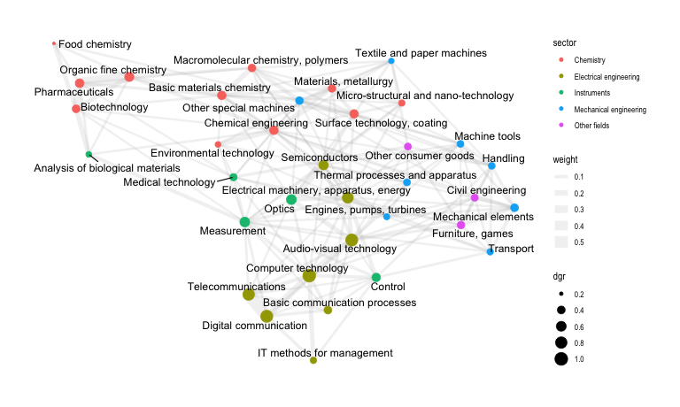

```r
library(ggraph)
g_tech %>%
  ggraph(layout =  coords_tech) +
  geom_edge_link(aes(width = weight), alpha = 0.2, colour = "grey") +
  geom_node_point(aes(colour = sector, size = dgr)) +
  geom_node_text(aes(label = field_name), size = 4, repel = TRUE) +
  theme_graph()
```

Lets see which tech-field is the most central (complex) one:

```r
g_tech %N>%
  arrange(desc(dgr)) %>%
  as_tibble() %>%
  slice(1:10)
```

| name | sector | field_name | dgr |
| --- | --- | --- | --- |
| 6 | Electrical engineering | Computer technology | 1.0000000 |
| 4 | Electrical engineering | Digital communication | 0.8964893 |
| 2 | Electrical engineering | Audio-visual technology | 0.8951385 |
| 3 | Electrical engineering | Telecommunications | 0.8247798 |
| 1 | Electrical engineering | Electrical machinery, apparatus, energy | 0.7314700 |
| 9 | Instruments | Optics | 0.6038599 |
| 10 | Instruments | Measurement | 0.5933025 |
| 8 | Electrical engineering | Semiconductors | 0.5570694 |
| 14 | Chemistry | Organic fine chemistry | 0.5246693 |
| 16 | Chemistry | Pharmaceuticals | 0.4795009 |

And the least one…

```r
g_tech %N>%
  arrange(dgr) %>%
  as_tibble() %>%
  slice(1:10)
```

| name | sector | field_name | dgr |
| --- | --- | --- | --- |
| 18 | Chemistry | Food chemistry | 0.1947224 |
| 28 | Mechanical engineering | Textile and paper machines | 0.2599749 |
| 24 | Chemistry | Environmental technology | 0.2711145 |
| 11 | Instruments | Analysis of biological materials | 0.2716099 |
| 27 | Mechanical engineering | Engines, pumps, turbines | 0.2912000 |
| 22 | Chemistry | Micro-structural and nano-technology | 0.3002927 |
| 32 | Mechanical engineering | Transport | 0.3067894 |
| 7 | Electrical engineering | IT methods for management | 0.3073732 |
| 25 | Mechanical engineering | Handling | 0.3264650 |
| 26 | Mechanical engineering | Machine tools | 0.3293354 |

Optimally, one would have created this space on world-data, and not only Chinese patents, though. Let’s, now that we know the overall space, take a look at city level specialization and complexity.

## Specialization pattern of cities

We here first join our city level patent data with the technology fields. Since a patent can have multiple ones, we this time fractionalize it with a `field_weight`.

```r
reg_tech <- reg_pat %>%
  left_join(el_pat_tech %>% select(appln_id, techn_field_nr), by = "appln_id") %>%
  group_by(appln_id) %>%
  mutate(field_weight = 1 / n()) %>%
  ungroup()
```

```r
reg_tech %<>%
  group_by(city, techn_field_nr) %>%
  summarise(n_tech_reg = sum(field_weight)) %>%
  ungroup() %>%
  drop_na()
```

Now, we for the `EconGeo` package again have to transform it to a matrix. Again, we have to set the rownames, which are depreciated in the `tibble`

```r
mat_reg_tech <- reg_tech %>%
  arrange(techn_field_nr, city) %>%
  pivot_wider(names_from = techn_field_nr, values_from = n_tech_reg, values_fill = list(n_tech_reg = 0))

rn_save <- mat_reg_tech %>% pull(city)

mat_reg_tech %<>% select(-city) %>%
  as.matrix() %>%
  round()

rownames(mat_reg_tech) <- rn_save
```

Lets take a look:

```r
mat_reg_tech[1:10, 1:10]
```

```
            1    2    3    4   5    6   7    8    9  10
baicheng    1    0    0    0   0    0   0    0    0   0
baoding     1    0    0    0   1    0   0    1    2   3
baoji       3    0    0    0   0    1   0    0    0   0
baotou      1    0    0    0   0    1   0    0    0   0
beijing   802 1452 1202 3114 230 4807 152 1519 1143 666
cangzhou    0    0    0    0   0    0   0    0    0   0
changchun   9    0    0    0   0    1   0   10    3   7
changsha   10    1    1    2   0    9   0    1    2   8
changshu    5    4    1    0   0    1   0    1    1   0
changzhou  20    1    0    4   0    5   0    2    1   8
```

```r
reg_RCA <- mat_reg_tech %>% location.quotient(binary = TRUE) %>%
  as.data.frame() %>%
  rownames_to_column("city") %>%
  as_tibble() %>%
  gather(key = "tech_field", value = "RCA", -city) %>%
  arrange(city, tech_field)
```

```r
reg_RCA %>% head()
```

| city | tech_field | RCA |
| --- | --- | --- |
| anqing | 1 | 0 |
| anqing | 10 | 0 |
| anqing | 11 | 0 |
| anqing | 12 | 0 |
| anqing | 13 | 0 |
| anqing | 14 | 1 |

The `Herfindahl()` function computes the Herfindahl index from regions - industries matrices from (incidence) regions - industries matrices. It is a measure of concentration. This index is also known as the Herfindahl-Hirschman index (Herfindahl, 1959; Hirschman, 1945).

```r
mat_reg_tech %>%
  Herfindahl() %>%
  as.data.frame() %>%
  rownames_to_column("city") %>%
  rename(HH = ".") %>%
  arrange(desc(HH)) %>%
  head(10)
```

|  | city | HH |
| --- | --- | --- |
| 1 | jingmen | 1 |
| 2 | lin'an | 1 |
| 3 | liuzhou | 1 |
| 4 | pingshan | 1 |
| 5 | rugao | 1 |
| 6 | yiyang | 1 |
| 7 | yuncheng | 1 |
| 8 | bengbu | 1 |
| 9 | yulin | 1 |
| 10 | putian | 1 |

Next, we can compute the Shannon entropy index (Shannon and Weaver, 1949; Frenken et al., 2007) from regions - industries matrices from (incidence) regions - industries matrices.

```r
mat_reg_tech %>%
  entropy() %>%
  as.data.frame() %>%
  rownames_to_column("city") %>%
  rename(SE = ".") %>%
  arrange(desc(SE)) %>%
  head(10)
```

|  | city | SE |
| --- | --- | --- |
| 1 | guangzhou | 4.691 |
| 2 | suzhou | 4.615 |
| 3 | qingdao | 4.545 |
| 4 | changsha | 4.499 |
| 5 | nanjing | 4.497 |
| 6 | ningbo | 4.431 |
| 7 | wuhan | 4.416 |
| 8 | shanghai | 4.357 |
| 9 | dalian | 4.316 |
| 10 | wuxi | 4.299 |

Now, finally, we can inspect where in the technology space different cities are specialized. We select some of interest.

```r
city_select <- c("beijing", "shanghai", "shenzhen")
```

In the following, I plot the technology-space and highlights in red the fields where the city has an RCA.

### Beijing

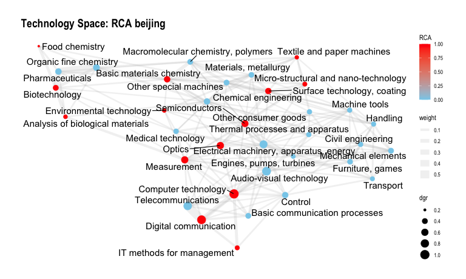

```r
i = 1
g_tech %N>%
  left_join(reg_RCA %>% filter(city == city_select[i]) %>% select(-city), by = c("name" = "tech_field")) %>%
  ggraph(layout = coords_tech) +
  geom_edge_link(aes(width = weight), alpha = 0.2, colour = "grey") +
  geom_node_point(aes(colour = RCA, size = dgr)) +
  geom_node_text(aes(label = field_name), size = 5, repel = TRUE) +
  scale_color_gradient(low = "skyblue", high = "red") +
  theme_graph() +
  ggtitle(paste("Technology Space: RCA", city_select[i], sep = " "))
```

### Shanghai

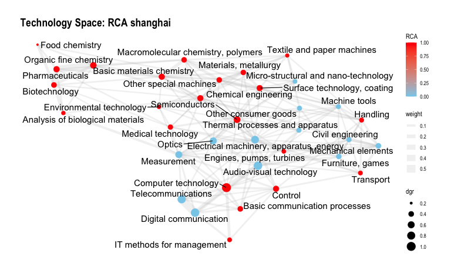

```r
i = 2
g_tech %N>%
  left_join(reg_RCA %>% filter(city == city_select[i]) %>% select(-city), by = c("name" = "tech_field")) %>%
  ggraph(layout = coords_tech) +
  geom_edge_link(aes(width = weight), alpha = 0.2, colour = "grey") +
  geom_node_point(aes(colour = RCA, size = dgr)) +
  geom_node_text(aes(label = field_name), size = 5, repel = TRUE) +
  scale_color_gradient(low = "skyblue", high = "red") +
  theme_graph() +
  ggtitle(paste("Technology Space: RCA", city_select[i], sep = " "))
```

### Shenzhen

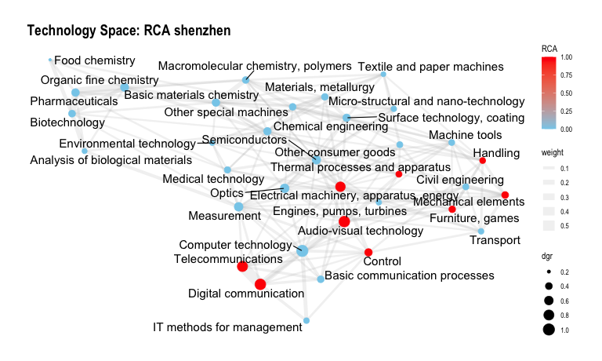

```r
i = 3
g_tech %N>%
  left_join(reg_RCA %>% filter(city == city_select[i]) %>% select(-city), by = c("name" = "tech_field")) %>%
  ggraph(layout = coords_tech) +
  geom_edge_link(aes(width = weight), alpha = 0.2, colour = "grey") +
  geom_node_point(aes(colour = RCA, size = dgr)) +
  geom_node_text(aes(label = field_name), size = 5, repel = TRUE) +
  scale_color_gradient(low = "skyblue", high = "red") +
  theme_graph() +
  ggtitle(paste("Technology Space: RCA", city_select[i], sep = " "))
```

So, what differences do we see?

# Endnotes

### More info

You can find more info about:

#### Data

- [`Economic Complexity Data`](https://atlas.cid.harvard.edu/)